# R Markdown Practice

Kagwiria Regina Nkonge

4/11/2020

## **About me**

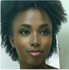

Kagwiria Nkonge.

My name is Kagwiria Regina Nkonge. I am a graduate student (class of 2020) at Harris School of Public Policy, *studying MA International Development and Policy*. I come from Kenya and I am an Obama Foundation Scholar. *My policy interests are international development, security, conflict and humanitarian intervention as well as technology and education*. Prior to coming to Harris my work focused on technology for development particularly the application of technology in higher education, refugee camps and hard to reach areas. I hold an MSc. in Information Systems Security and Digital Forensics.

**I’m excited to be in this class!**

## **Purpose of this project**

The goal of this project is to test my software installation skills, GitHub setup, and homework submission process via pull request, as well as demonstrate competency in Markdown. At first I used R Markdown formatting on the README.md file, but things did not seem right as I could not Knit it. That’s when I decided to create an R Markdown file.

### **How I created this Readme file**

- I installed Git *(R studio was already installed in my computer)*
- I forked and cloned the hw01 repository
- I opened the README file using R Studio and Git as the version control software
- I edited the README: added the following sections - about me, purpose of this project, how I created this file
- I stages and commited the file, then pushed it to GitHub
- Then I opened a new R Markdown file on R Studio, and practised my R Markdown skills on the same information I put in my README file
- I commited again and pushed to GitHub

## **Reflection**

The process was a bit confusing because I have not used Git before, and so at first I was using GitHub desktop, only to realize that Git and GitHub are different.

## **Links that I found useful**

[hw01 Video](https://cfss.uchicago.edu/homework/edit-readme/)

[Getting Started With R Markdown](https://rstudio.com/resources/webinars/getting-started-with-r-markdown/)

[R Markdown Cheat Sheet](https://guides.github.com/pdfs/markdown-cheatsheet-online.pdf)